## Final Exam Extra Questions

Here are the questions I received on Polly. Due to the nature of them I will just answer them via this page instead of a video.

- I know hazard h(t) is a derivative of survival S(t), so are there interpretations different? Do I have x chance of survival or x hazard of getting disease?
- When the proportional hazards assumption is violated, we can include a ‘strata’ term… does this alter our interpretation of the beta coefficient? or do you include this as conditional statement? For example: adjusting for the ’strata’term, we expect that the hazard rate increases by X for every 1 year increase in age.
- Can you confirm what topics the final exam material will go through? thank you!
- Perhaps you can go over an example where you use logistic, poisson, and Cox and compare and contrast the results you obtain. That would be pretty helpful!

## Hazard vs Survival

The hazard is actually the negative of the derivative of the natural logarithm of survival.

$$h(t) = -\dfrac{d}{dt}log\left[S(t)\right]$$
They do not have the same meaning. Survival is a probability of surviving past a certain time $t$ or $\Pr(T>t)$. However, the hazard is the instantaneous rate of failure at time $t$.

This means survival is basically trying to calculate the proportion of individuals who have survived past some time $t$ and hazard would be the rate at which we expect subjects to fail at time $t$.

Anytime you are discussing different concepts, then there are different interpretations. Consider Lecture 13 from slide 8 - 13 for the definitions of survival and hazard. Then consider Lecture 14 slides 13-22 for interpretations.

## Stratified Cox PH Models

When we stratify the Cox Proportional Hazards models we are startifying the baseline hazard function which we do not interpret. Consider the example from Lecture 14

We began fitting a model to look at modeling the hazard of going back to prison within 1 year of being released. We found that `age` did not pass the proportional hazards test. We placed age into categories to stratify over.

Then we fit the model with stratified age:

| term | estimate | p.value | conf.low | conf.high |
| --- | --- | --- | --- | --- |
| finyes | 0.711198 | 0.0731668 | 0.4898793 | 1.032505 |
| prio | 1.098636 | 0.0004973 | 1.0419799 | 1.158373 |

We can plot the model to see the effects of stratification:

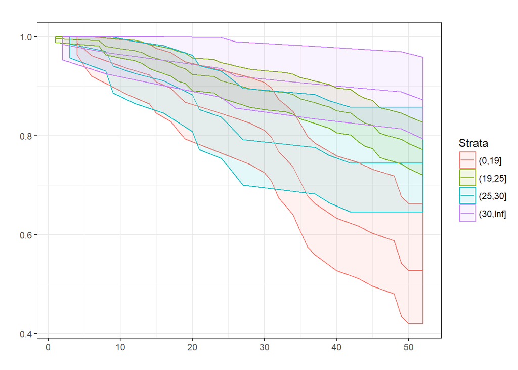

We can see that the strate do give us different survival curves. This is do to the different baseline hazard ratios. However the model output is the same regardless of which age category an individual is in:

| term | estimate | p.value | conf.low | conf.high |
| --- | --- | --- | --- | --- |
| finyes | 0.711198 | 0.0731668 | 0.4898793 | 1.032505 |
| prio | 1.098636 | 0.0004973 | 1.0419799 | 1.158373 |

We do however account for age in the interpretation. For example if we were to interpret `fin`, we would see that if we compare 2 people in the same age category and the same numer of prior convictions for an individual who receives financial support they have a 28.9% decrease in hazard of returning to prison as the one who did not receive financial support.

## Exam Material

As I mentioned in class, I am not going to give complete lists of everything on the exam. However the main concepts being tested on the exam will be:

- Logistic Regression
- Poisson Regression
- Cox PH Models

You can find the notes on this in the calendar section of the website. I have also provided a practice exam.

## Model Comparisons

Let’s consider the Recividivism data of Lecture 14. We wish to model whether or not a released prisoner will return to prison. If we fit our model with logistic regression we get:

| term | estimate | p.value |
| --- | --- | --- |
| (Intercept) | 0.8302458 | 0.5398357 |
| finyes | 0.6592192 | 0.0697542 |
| prio | 1.1089695 | 0.0057502 |
| age.cat(19,25] | 0.3258687 | 0.0001494 |
| age.cat(25,30] | 0.3873753 | 0.0129659 |
| age.cat(30,Inf] | 0.1621535 | 0.0000677 |

We find that if we are interested in whether or not financial assistance helps then would look at the `fin` variable in the model and see that this is not significant. We have a p-value of 0.07.

This model assumes that we follow subjects for the same time period. If we look at the density of of time.

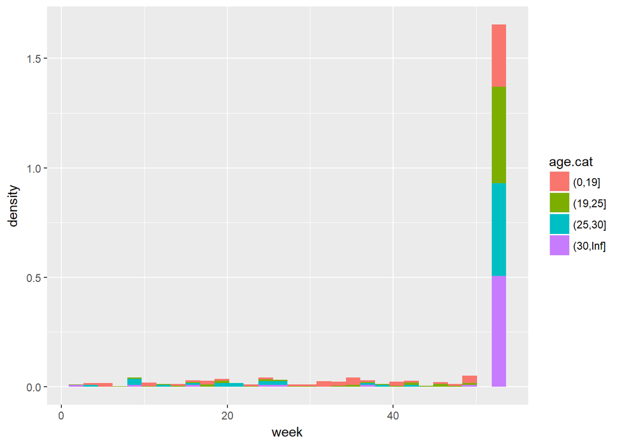

We can see that just in the individual age groups that there is quite the variation of time and this may violate the assumption of same time for each individual. We then may wish to consider Poisson regression instead.

| term | estimate | p.value |
| --- | --- | --- |
| (Intercept) | 0.4394671 | 0.0002833 |
| finyes | 0.7613478 | 0.1516880 |
| prio | 1.0602218 | 0.0247865 |
| age.cat(19,25] | 0.5051420 | 0.0020580 |
| age.cat(25,30] | 0.5656266 | 0.0586176 |
| age.cat(30,Inf] | 0.2815092 | 0.0014321 |

We can also see that in this model `fin` is not significant with a p-value of 0.15. With this model we are assuming that the rate at which a subject is likely to go back to prison remains the same. This may be violated in that we can assume that the longer a subject is out, the less likely they are to return to prison. This would then suggest that we cannot use Poisson and cannot use logistic. Now we are left with a survival model of Cox Proportional hazards:

| term | estimate | p.value | conf.low | conf.high |
| --- | --- | --- | --- | --- |
| finyes | 0.711198 | 0.0731668 | 0.4898793 | 1.032505 |
| prio | 1.098636 | 0.0004973 | 1.0419799 | 1.158373 |

We also find in this model that `fin` is not significant which is the same result as we have had in all previous models but the data is better modeled by Cox PH in this case.